# AIMG Survey Data Analysis

# Load packages, clear environment, set seed, and turn scientific notation off

```r
rm(list = ls())
options(contrasts = c("contr.sum","contr.poly"), scipen = 12)
set.seed(42)

if (!require("pacman")) install.packages("pacman");
library(pacman)
pacman::p_load(tidyverse, dplyr,car, Hmisc, psych, TOSTER, lavaan, forcats, MuMIn, likert, QuantPsyc, lavaanPlot, semPlot, ggpubr, DescTools, lm.beta, rcompanion, cowplot, PupillometryR, viridis, patchwork)
```

# Import raw data

Note: Must export detailed response info csv + incomplete responses

```r
raw_data <- read_csv("Raw_Data/raw_data.csv")
```

# Data cleaning

## Remove test responses before 19 November

```r
raw_data <- raw_data %>% filter(Started > "11/19/2020 12:00:00")
```

## remove incomplete responses

(using the `Ended` variable to determine if the survey was submitted)

```r
raw_data %>% tally() #initial number of responses:
```

| n |
| --- |
| 2990 |

```r
raw_data <- raw_data %>% filter(!is.na(Ended))
raw_data %>% tally() #number of responses after removing incomplete:
```

| n |
| --- |
| 1770 |

## Remove responses for which consent was not provided

```r
raw_data %>% tally() #initial number of responses:
```

| n |
| --- |
| 1770 |

```r
raw_data <- raw_data %>% filter(consent_consent_1_Column2 == "yes" & consent_consent_2_Column2 == "yes")
raw_data %>% tally() #number of responses after removing incomplete
```

| n |
| --- |
| 1752 |

## Demographic variable recoding and descriptive statistics

Produce age variable from birth year

```r
raw_data <- raw_data %>%
  mutate(age = as.numeric(2020 - as.numeric(birth_year))) %>% dplyr::select(-birth_year)

raw_data %>% summarise(m = mean(age), sd = sd(age))
```

| m | sd |
| --- | --- |
| 21.12158 | 2.808479 |

Clean study year variable

```r
raw_data<- raw_data %>%
  mutate(study_year = as.factor(case_when(year_study == "First Year" ~ "First Year",
                                year_study == "Second Year" ~ "Second Year",
                                year_study == "Third Year" ~ "Third Year",
                                year_study == "Fourth Year" ~ "Fourth Year",
                                TRUE ~ "Other"))) %>% dplyr::select(-year_study)

raw_data %>%
  group_by(study_year) %>%
  summarise(n=n()) %>%
  mutate(perc = n/sum(n)*100)
```

| study_year | n | perc |
| --- | --- | --- |
| First Year | 471 | 26.883562 |
| Fourth Year | 230 | 13.127854 |
| Other | 68 | 3.881279 |
| Second Year | 492 | 28.082192 |
| Third Year | 491 | 28.025114 |

Gender descriptive statistics

```r
raw_data <- raw_data %>%
  mutate(gender = as.factor(case_when(gender == "female" ~"female",
                                      gender == "male" ~ "male",
                                      TRUE ~ "other")))
raw_data %>%
  group_by(gender) %>%
  summarise(n=n()) %>%
  mutate(perc = n/sum(n)*100)
```

| gender | n | perc |
| --- | --- | --- |
| female | 1109 | 63.2990868 |
| male | 634 | 36.1872146 |
| other | 9 | 0.5136986 |

Faculty descriptive statistics

```r
raw_data<- raw_data %>%
  mutate(faculty = as.factor(faculty))

raw_data %>%
  group_by(faculty) %>%
  summarise(n=n()) %>%
  mutate(perc = n/sum(n)*100)
```

| faculty | n | perc |
| --- | --- | --- |
| AgriSciences | 115 | 6.5639269 |
| Arts and Social Sciences | 278 | 15.8675799 |
| Economic and Management Sciences | 339 | 19.3493151 |
| Education | 74 | 4.2237443 |
| Engineering | 324 | 18.4931507 |
| Law | 98 | 5.5936073 |
| Medicine and Health Sciences | 271 | 15.4680365 |
| Military Science | 6 | 0.3424658 |
| Science | 228 | 13.0136986 |
| Theology | 19 | 1.0844749 |

Remove extraneous columns now that checks are complete

```r
raw_data <- raw_data %>% dplyr::select(-c(ResponseID, ResponseGuid, Started, Ended, TotalTime, LastEdit,
                                   IP, Language, UniqueIdentifier, Invitee, Score,
                                   consent_consent_1_Column2, consent_consent_2_Column2))
```

## Create and test scales for dependent variables

### Academic stress scale

https://doi.org/10.1375/ajgc.19.1.56

Responses are coded: 1 - 5, no reverse coding, 21 items “Items are summed for subscale scores and subscales are summed for a total LASRS stress response score.” “Higher scores indicate a greater stress response.”

(columns written out rather than looping in case column numbers change)

```r
raw_data <-raw_data %>%
  mutate(academic_stress_scale = academic_stress_academic_stress_1_Column2 + academic_stress_academic_stress_2_Column2 +
                                    academic_stress_academic_stress_3_Column2 + academic_stress_academic_stress_4_Column2 +
                                    academic_stress_academic_stress_5_Column2 + academic_stress_academic_stress_6_Column2 +
                                    academic_stress_academic_stress_7_Column2 + academic_stress_academic_stress_8_Column2 +
                                    academic_stress_academic_stress_9_Column2 + academic_stress_academic_stress_10_Column2 +
                                    academic_stress_academic_stress_11_Column2 + academic_stress_academic_stress_12_Column2 +
                                    academic_stress_academic_stress_13_Column2 + academic_stress_academic_stress_14_Column2 +
                                    academic_stress_academic_stress_15_Column2 + academic_stress_academic_stress_16_Column2 +
                                    academic_stress_academic_stress_17_Column2 + academic_stress_academic_stress_18_Column2 +
                                    academic_stress_academic_stress_19_Column2 + academic_stress_academic_stress_20_Column2 +
                                    academic_stress_academic_stress_21_Column2)
```

Cronbach’s alpha for internal consistency (can consider doing CFI to check factor structure correspondence with original)

```r
raw_data %>%
  dplyr::select(academic_stress_academic_stress_1_Column2, academic_stress_academic_stress_2_Column2,
         academic_stress_academic_stress_3_Column2, academic_stress_academic_stress_4_Column2,
         academic_stress_academic_stress_5_Column2, academic_stress_academic_stress_6_Column2,
         academic_stress_academic_stress_7_Column2, academic_stress_academic_stress_8_Column2,
         academic_stress_academic_stress_9_Column2, academic_stress_academic_stress_10_Column2,
         academic_stress_academic_stress_11_Column2, academic_stress_academic_stress_12_Column2,
         academic_stress_academic_stress_13_Column2, academic_stress_academic_stress_14_Column2,
         academic_stress_academic_stress_15_Column2, academic_stress_academic_stress_16_Column2,
         academic_stress_academic_stress_17_Column2, academic_stress_academic_stress_18_Column2,
         academic_stress_academic_stress_19_Column2, academic_stress_academic_stress_20_Column2,
         academic_stress_academic_stress_21_Column2) %>%
  alpha()
```

```
Reliability analysis
Call: alpha(x = .)
```

|  | raw_alpha | std.alpha | G6(smc) | average_r | S/N | ase | mean | sd | median_r |
| --- | --- | --- | --- | --- | --- | --- | --- | --- | --- |
|  | 0.9097528 | 0.9095427 | 0.9316802 | 0.3237791 | 10.05494 | 0.003091959 | 2.667401 | 0.65721 | 0.3045098 |

```
 lower alpha upper     95% confidence boundaries
0.9 0.91 0.92

 Reliability if an item is dropped:
```

|  | raw_alpha | std.alpha | G6(smc) | average_r | S/N | alpha se | var.r | med.r |
| --- | --- | --- | --- | --- | --- | --- | --- | --- |
| academic_stress_academic_stress_1_Column2 | 0.9028592 | 0.9028120 | 0.9255661 | 0.3171575 | 9.289332 | 0.003340426 | 0.02346198 | 0.3015077 |
| academic_stress_academic_stress_2_Column2 | 0.9036492 | 0.9034555 | 0.9258283 | 0.3187527 | 9.357916 | 0.003310075 | 0.02384924 | 0.3015077 |
| academic_stress_academic_stress_3_Column2 | 0.9021695 | 0.9020377 | 0.9257430 | 0.3152562 | 9.208004 | 0.003364621 | 0.02467674 | 0.2994448 |
| academic_stress_academic_stress_4_Column2 | 0.9073691 | 0.9071958 | 0.9307295 | 0.3283040 | 9.775376 | 0.003180668 | 0.02650677 | 0.3088616 |
| academic_stress_academic_stress_5_Column2 | 0.9027728 | 0.9026806 | 0.9262608 | 0.3168336 | 9.275444 | 0.003343573 | 0.02376785 | 0.3007466 |
| academic_stress_academic_stress_6_Column2 | 0.9072744 | 0.9069243 | 0.9274661 | 0.3275942 | 9.743942 | 0.003164620 | 0.02513904 | 0.3119343 |
| academic_stress_academic_stress_7_Column2 | 0.9091261 | 0.9086098 | 0.9284304 | 0.3320440 | 9.942090 | 0.003100332 | 0.02408620 | 0.3150354 |
| academic_stress_academic_stress_8_Column2 | 0.9080321 | 0.9077156 | 0.9272180 | 0.3296704 | 9.836067 | 0.003136549 | 0.02419195 | 0.3150354 |
| academic_stress_academic_stress_9_Column2 | 0.9037149 | 0.9031080 | 0.9264259 | 0.3178896 | 9.320767 | 0.003295811 | 0.02563591 | 0.2998511 |
| academic_stress_academic_stress_10_Column2 | 0.9061848 | 0.9057951 | 0.9257582 | 0.3246703 | 9.615163 | 0.003201224 | 0.02517303 | 0.3079006 |

[output cut: 11 more lines]

```
 Item statistics
```

|  | n | raw.r | std.r | r.cor | r.drop | mean | sd |
| --- | --- | --- | --- | --- | --- | --- | --- |
| academic_stress_academic_stress_1_Column2 | 1752 | 0.7021645 | 0.6970527 | 0.6911769 | 0.6562129 | 3.012557 | 1.1450297 |
| academic_stress_academic_stress_2_Column2 | 1752 | 0.6760680 | 0.6728625 | 0.6647564 | 0.6309577 | 3.229452 | 1.0600907 |
| academic_stress_academic_stress_3_Column2 | 1752 | 0.7278321 | 0.7258850 | 0.7162215 | 0.6857737 | 2.662671 | 1.1274162 |
| academic_stress_academic_stress_4_Column2 | 1752 | 0.5261210 | 0.5280241 | 0.4864476 | 0.4669092 | 2.047374 | 1.0642060 |
| academic_stress_academic_stress_5_Column2 | 1752 | 0.7073919 | 0.7019648 | 0.6922336 | 0.6639959 | 3.601027 | 1.1003655 |
| academic_stress_academic_stress_6_Column2 | 1752 | 0.5342544 | 0.5387885 | 0.5202201 | 0.4733638 | 3.128425 | 1.1039890 |
| academic_stress_academic_stress_7_Column2 | 1752 | 0.4664049 | 0.4713107 | 0.4489864 | 0.3981820 | 3.179795 | 1.1376845 |
| academic_stress_academic_stress_8_Column2 | 1752 | 0.4978581 | 0.5073047 | 0.4931722 | 0.4368503 | 2.960046 | 1.0583230 |
| academic_stress_academic_stress_9_Column2 | 1752 | 0.6787804 | 0.6859512 | 0.6733372 | 0.6371655 | 2.693493 | 0.9894953 |
| academic_stress_academic_stress_10_Column2 | 1752 | 0.5732832 | 0.5831274 | 0.5741194 | 0.5195699 | 2.888128 | 1.0356504 |

[output cut: 11 more lines]

```
Non missing response frequency for each item
                                              1    2    3    4    5 miss
academic_stress_academic_stress_1_Column2  0.12 0.19 0.34 0.26 0.09    0
academic_stress_academic_stress_2_Column2  0.06 0.18 0.37 0.27 0.12    0
academic_stress_academic_stress_3_Column2  0.18 0.27 0.34 0.15 0.07    0
academic_stress_academic_stress_4_Column2  0.39 0.29 0.22 0.06 0.03    0
academic_stress_academic_stress_5_Column2  0.05 0.11 0.28 0.32 0.24    0
academic_stress_academic_stress_6_Column2  0.07 0.22 0.34 0.24 0.12    0
academic_stress_academic_stress_7_Column2  0.07 0.21 0.31 0.26 0.14    0
academic_stress_academic_stress_8_Column2  0.08 0.26 0.35 0.22 0.08    0
academic_stress_academic_stress_9_Column2  0.10 0.34 0.37 0.14 0.05    0
academic_stress_academic_stress_10_Column2 0.08 0.30 0.36 0.19 0.07    0
academic_stress_academic_stress_11_Column2 0.41 0.30 0.19 0.07 0.03    0
academic_stress_academic_stress_12_Column2 0.60 0.18 0.14 0.05 0.02    0
academic_stress_academic_stress_13_Column2 0.16 0.36 0.34 0.11 0.03    0
academic_stress_academic_stress_14_Column2 0.68 0.15 0.12 0.03 0.02    0
academic_stress_academic_stress_15_Column2 0.59 0.19 0.13 0.07 0.02    0
academic_stress_academic_stress_16_Column2 0.47 0.23 0.16 0.10 0.03    0
academic_stress_academic_stress_17_Column2 0.23 0.23 0.24 0.20 0.10    0
academic_stress_academic_stress_18_Column2 0.22 0.24 0.27 0.18 0.08    0
academic_stress_academic_stress_19_Column2 0.05 0.17 0.29 0.32 0.18    0
academic_stress_academic_stress_20_Column2 0.06 0.16 0.27 0.30 0.21    0
academic_stress_academic_stress_21_Column2 0.13 0.26 0.28 0.19 0.13    0
```

Produce academic stress subscales

```r
raw_data <- raw_data %>%
  mutate(AS_affective = academic_stress_academic_stress_20_Column2 +
           academic_stress_academic_stress_19_Column2 +
           academic_stress_academic_stress_6_Column2 +
           academic_stress_academic_stress_12_Column2,
         AS_behavioural = academic_stress_academic_stress_3_Column2 +
           academic_stress_academic_stress_11_Column2 +
           academic_stress_academic_stress_17_Column2 +
           academic_stress_academic_stress_16_Column2 +
           academic_stress_academic_stress_1_Column2 +
           academic_stress_academic_stress_8_Column2 +
           academic_stress_academic_stress_2_Column2 +
           academic_stress_academic_stress_7_Column2,
         AS_physiological = academic_stress_academic_stress_9_Column2 +
           academic_stress_academic_stress_21_Column2 +
           academic_stress_academic_stress_14_Column2 +
           academic_stress_academic_stress_15_Column2 +
           academic_stress_academic_stress_10_Column2,
         AS_Cognitive = academic_stress_academic_stress_18_Column2 +
           academic_stress_academic_stress_4_Column2 +
           academic_stress_academic_stress_13_Column2 +
           academic_stress_academic_stress_5_Column2)
```

Remove unnecessary columns

```r
raw_data <- raw_data %>% dplyr::select(-c(academic_stress_academic_stress_1_Column2, academic_stress_academic_stress_2_Column2,
         academic_stress_academic_stress_3_Column2, academic_stress_academic_stress_4_Column2,
         academic_stress_academic_stress_5_Column2, academic_stress_academic_stress_6_Column2,
         academic_stress_academic_stress_7_Column2, academic_stress_academic_stress_8_Column2,
         academic_stress_academic_stress_9_Column2, academic_stress_academic_stress_10_Column2,
         academic_stress_academic_stress_11_Column2, academic_stress_academic_stress_12_Column2,
         academic_stress_academic_stress_13_Column2, academic_stress_academic_stress_14_Column2,
         academic_stress_academic_stress_15_Column2, academic_stress_academic_stress_16_Column2,
         academic_stress_academic_stress_17_Column2, academic_stress_academic_stress_18_Column2,
         academic_stress_academic_stress_19_Column2, academic_stress_academic_stress_20_Column2,
         academic_stress_academic_stress_21_Column2))
```

### Learning Community Scale

Responses are coded: 1 - 5, no reverse coding, and aggregated

```r
raw_data <- raw_data %>%
  mutate(LCS = (EQ_LCS_1_Column2+EQ_LCS_2_Column2+EQ_LCS_3_Column2+EQ_LCS_4_Column2+EQ_LCS_5_Column2)/5)
```

Cronbach’s alpha

```r
raw_data %>% dplyr::select(EQ_LCS_1_Column2, EQ_LCS_2_Column2,
                    EQ_LCS_3_Column2, EQ_LCS_4_Column2,
                    EQ_LCS_5_Column2) %>% alpha()
```

```
Reliability analysis
Call: alpha(x = .)
```

|  | raw_alpha | std.alpha | G6(smc) | average_r | S/N | ase | mean | sd | median_r |
| --- | --- | --- | --- | --- | --- | --- | --- | --- | --- |
|  | 0.8054118 | 0.8076441 | 0.7786893 | 0.4564448 | 4.198698 | 0.007378697 | 3.346575 | 0.7237031 | 0.4418644 |

```
 lower alpha upper     95% confidence boundaries
0.79 0.81 0.82

 Reliability if an item is dropped:
```

|  | raw_alpha | std.alpha | G6(smc) | average_r | S/N | alpha se | var.r | med.r |
| --- | --- | --- | --- | --- | --- | --- | --- | --- |
| EQ_LCS_1_Column2 | 0.7629795 | 0.7659775 | 0.7183425 | 0.4500277 | 3.273093 | 0.009299679 | 0.005871293 | 0.4337455 |
| EQ_LCS_2_Column2 | 0.7384811 | 0.7400653 | 0.6844818 | 0.4158128 | 2.847121 | 0.010196109 | 0.002435838 | 0.4165797 |
| EQ_LCS_3_Column2 | 0.7624614 | 0.7650143 | 0.7179746 | 0.4487000 | 3.255577 | 0.009309427 | 0.006473777 | 0.4534539 |
| EQ_LCS_4_Column2 | 0.7982927 | 0.8005325 | 0.7580706 | 0.5008328 | 4.013347 | 0.007905380 | 0.004232801 | 0.4793024 |
| EQ_LCS_5_Column2 | 0.7760490 | 0.7779056 | 0.7354952 | 0.4668507 | 3.502590 | 0.008799652 | 0.008921772 | 0.4416248 |

```
 Item statistics
```

|  | n | raw.r | std.r | r.cor | r.drop | mean | sd |
| --- | --- | --- | --- | --- | --- | --- | --- |
| EQ_LCS_1_Column2 | 1752 | 0.7563866 | 0.7620117 | 0.6822040 | 0.6076215 | 3.494863 | 0.9261583 |
| EQ_LCS_2_Column2 | 1752 | 0.8112387 | 0.8166267 | 0.7740344 | 0.6866222 | 3.321347 | 0.9372309 |
| EQ_LCS_3_Column2 | 1752 | 0.7573925 | 0.7641311 | 0.6850567 | 0.6094767 | 3.344749 | 0.9242503 |
| EQ_LCS_4_Column2 | 1752 | 0.6863991 | 0.6809147 | 0.5446121 | 0.4927572 | 3.073059 | 0.9935970 |
| EQ_LCS_5_Column2 | 1752 | 0.7465728 | 0.7351581 | 0.6310221 | 0.5682583 | 3.498858 | 1.0389331 |

```
Non missing response frequency for each item
                    1    2    3    4    5 miss
EQ_LCS_1_Column2 0.03 0.10 0.31 0.45 0.11    0
EQ_LCS_2_Column2 0.04 0.14 0.36 0.38 0.08    0
EQ_LCS_3_Column2 0.03 0.14 0.35 0.40 0.08    0
EQ_LCS_4_Column2 0.07 0.20 0.38 0.30 0.05    0
EQ_LCS_5_Column2 0.05 0.12 0.27 0.42 0.15    0
```

### Good Teaching Scale

Responses are coded: 1 - 5, no reverse coding, and aggregated

```r
raw_data <- raw_data %>%
  mutate(GTS = (EQ_GTS_1_Column2+EQ_GTS_2_Column2+EQ_GTS_3_Column2+EQ_GTS_4_Column2+EQ_GTS_5_Column2)/5)
```

```r
raw_data %>% dplyr::select(EQ_GTS_1_Column2, EQ_GTS_2_Column2,
                    EQ_GTS_3_Column2, EQ_GTS_4_Column2,
                    EQ_GTS_5_Column2) %>% alpha()
```

```
Reliability analysis
Call: alpha(x = .)
```

|  | raw_alpha | std.alpha | G6(smc) | average_r | S/N | ase | mean | sd | median_r |
| --- | --- | --- | --- | --- | --- | --- | --- | --- | --- |
|  | 0.8509515 | 0.8495605 | 0.83272 | 0.5303926 | 5.647191 | 0.00555342 | 3.077169 | 0.8043737 | 0.5343209 |

```
 lower alpha upper     95% confidence boundaries
0.84 0.85 0.86

 Reliability if an item is dropped:
```

|  | raw_alpha | std.alpha | G6(smc) | average_r | S/N | alpha se | var.r | med.r |
| --- | --- | --- | --- | --- | --- | --- | --- | --- |
| EQ_GTS_1_Column2 | 0.8053363 | 0.8046411 | 0.7627405 | 0.5073154 | 4.118785 | 0.007484943 | 0.005404119 | 0.5084420 |
| EQ_GTS_2_Column2 | 0.8033909 | 0.8034659 | 0.7567604 | 0.5054510 | 4.088177 | 0.007553795 | 0.002458488 | 0.5114601 |
| EQ_GTS_3_Column2 | 0.8155206 | 0.8135246 | 0.7868161 | 0.5216820 | 4.362637 | 0.007090968 | 0.012915981 | 0.5084420 |
| EQ_GTS_4_Column2 | 0.8497504 | 0.8496819 | 0.8203083 | 0.5856021 | 5.652560 | 0.005892617 | 0.005652258 | 0.5542075 |
| EQ_GTS_5_Column2 | 0.8225863 | 0.8196706 | 0.7935184 | 0.5319123 | 4.545407 | 0.006781934 | 0.014930213 | 0.5038905 |

```
 Item statistics
```

|  | n | raw.r | std.r | r.cor | r.drop | mean | sd |
| --- | --- | --- | --- | --- | --- | --- | --- |
| EQ_GTS_1_Column2 | 1752 | 0.8335288 | 0.8251833 | 0.7871175 | 0.7160602 | 3.024543 | 1.0729914 |
| EQ_GTS_2_Column2 | 1752 | 0.8361279 | 0.8280149 | 0.7960578 | 0.7231004 | 2.903539 | 1.0533182 |
| EQ_GTS_3_Column2 | 1752 | 0.8028852 | 0.8033645 | 0.7337851 | 0.6799089 | 3.070205 | 1.0060822 |
| EQ_GTS_4_Column2 | 1752 | 0.6859416 | 0.7062872 | 0.5819439 | 0.5387591 | 3.331621 | 0.8872239 |
| EQ_GTS_5_Column2 | 1752 | 0.7904757 | 0.7878274 | 0.7062267 | 0.6538276 | 3.055936 | 1.0505548 |

```
Non missing response frequency for each item
                    1    2    3    4    5 miss
EQ_GTS_1_Column2 0.09 0.24 0.32 0.29 0.07    0
EQ_GTS_2_Column2 0.09 0.27 0.33 0.24 0.06    0
EQ_GTS_3_Column2 0.07 0.20 0.39 0.28 0.07    0
EQ_GTS_4_Column2 0.03 0.13 0.39 0.38 0.07    0
EQ_GTS_5_Column2 0.08 0.21 0.36 0.28 0.07    0
```

### Overall Satisfaction Index

```r
raw_data <- raw_data %>%
  mutate(OSI = as.factor(EQ_OSI_Column2)) %>%
  mutate(OSI = fct_relevel(OSI, c("1","2","3","4","5")))
```

Remove unnecessary columns

```r
raw_data <- raw_data %>% dplyr::select(-c(EQ_LCS_1_Column2, EQ_LCS_2_Column2,
                    EQ_LCS_3_Column2, EQ_LCS_4_Column2,
                    EQ_LCS_5_Column2, EQ_GTS_1_Column2, EQ_GTS_2_Column2,
                    EQ_GTS_3_Column2, EQ_GTS_4_Column2,
                    EQ_GTS_5_Column2, EQ_OSI_Column2))
```

## Descriptive statistics for Dependent variables

Note, OSI variable is categorical (ordinal) not numeric (indicated with an asterisk)

```r
raw_data %>%
  dplyr::select(academic_performance,
                    academic_stress_scale, AS_affective, AS_behavioural, AS_physiological, AS_Cognitive,
                    LCS, GTS, OSI) %>%
  psych::describe()
```

|  | vars | n | mean | sd | median | trimmed | mad | min | max | range | skew | kurtosis | se |
| --- | --- | --- | --- | --- | --- | --- | --- | --- | --- | --- | --- | --- | --- |
| academic_performance | 1 | 1752 | 6.64 | 1.80 | 7.0 | 6.63 | 1.48 | 1 | 11 | 10 | 0.07 | -0.35 | 0.04 |
| academic_stress_scale | 2 | 1752 | 56.02 | 13.80 | 55.0 | 55.57 | 13.34 | 21 | 105 | 84 | 0.32 | -0.05 | 0.33 |
| AS_affective | 3 | 1752 | 11.66 | 3.00 | 12.0 | 11.64 | 2.97 | 4 | 20 | 16 | 0.09 | -0.26 | 0.07 |
| AS_behavioural | 4 | 1752 | 21.76 | 5.58 | 22.0 | 21.61 | 5.93 | 8 | 40 | 32 | 0.27 | -0.17 | 0.13 |
| AS_physiological | 5 | 1752 | 11.81 | 3.69 | 11.0 | 11.57 | 2.97 | 5 | 25 | 20 | 0.66 | 0.37 | 0.09 |
| AS_Cognitive | 6 | 1752 | 10.79 | 3.08 | 11.0 | 10.72 | 2.97 | 4 | 20 | 16 | 0.19 | -0.31 | 0.07 |
| LCS | 7 | 1752 | 3.35 | 0.72 | 3.4 | 3.37 | 0.59 | 1 | 5 | 4 | -0.33 | 0.16 | 0.02 |
| GTS | 8 | 1752 | 3.08 | 0.80 | 3.0 | 3.09 | 0.89 | 1 | 5 | 4 | -0.07 | -0.07 | 0.02 |
| OSI* | 9 | 1752 | 3.78 | 0.88 | 4.0 | 3.87 | 0.00 | 1 | 5 | 4 | -0.92 | 1.05 | 0.02 |

## Produce AIMGs Usage scales

### Produce proportion values

First set the module proportion to factor and create new variables

```r
raw_data<-raw_data %>%
  mutate(use_proportion_formal_AIMG = as.factor(Group_Use_formal_AIMG_extent_Column2),
         use_proportion_class_AIMG = as.factor(Group_Use_class_AIMG_extent_Column2),
         use_proportion_study_AIMG = as.factor(Group_Use_group_AIMG_extent_Column2)) %>%
  dplyr::select(-c(Group_Use_formal_AIMG_extent_Column2,Group_Use_class_AIMG_extent_Column2,Group_Use_group_AIMG_extent_Column2))
```

```r
use_proportion <- raw_data %>% dplyr::select(use_proportion_formal_AIMG, use_proportion_class_AIMG, use_proportion_study_AIMG)

use_proportion_data <- pivot_longer(data = use_proportion, cols = c(use_proportion_formal_AIMG, use_proportion_class_AIMG, use_proportion_study_AIMG), names_to = "group_type", values_to = "response")
```

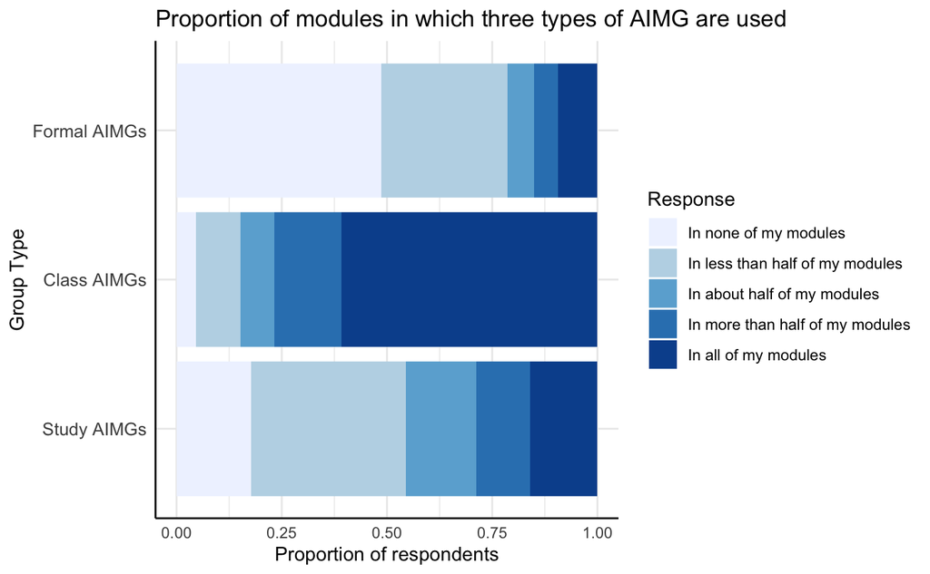

```r
use_proportion_figure<- use_proportion_data %>%
  mutate(response = factor(response)) %>%
  mutate(response = fct_relevel(response,
                                "In all of my modules", "In more than half of my modules", "In about half of my modules", "In less than half of my modules", "In none of my modules")) %>%
  mutate(group_type = factor(case_when(group_type == "use_proportion_formal_AIMG" ~"Formal AIMGs",
                                group_type == "use_proportion_class_AIMG" ~"Class AIMGs",
                                group_type == "use_proportion_study_AIMG" ~"Study AIMGs"), levels = c("Study AIMGs", "Class AIMGs", "Formal AIMGs"))) %>%
  group_by(group_type, response) %>%
  summarise(count = n()) %>%
  ggplot(aes(x = group_type, fill = response, y = count))+
  geom_bar(position = "fill", stat = "identity") +
  scale_fill_brewer(palette = "Blues", direction = -1)+
  labs(title = "Proportion of modules in which three types of AIMG are used", fill = "Response", y = "Proportion of respondents", x = "Group Type")+
  coord_flip() +
  theme_minimal() +
  theme(axis.line = element_line(colour = "black"),
        axis.text.y = element_text(size = 10)) +  guides(fill=guide_legend(reverse = TRUE))
use_proportion_figure

ggsave((filename="Figures/use_proportion_figure.pdf"), scale = 1, width = 10, height=5, dpi = 600, limitsize = TRUE, use_proportion_figure)
```

Recode to numeric from raw responses

```r
raw_data <- raw_data %>%
  mutate(use_proportion_formal_AIMG  = case_when(use_proportion_formal_AIMG == "In none of my modules" ~0,
                                              use_proportion_formal_AIMG == "In less than half of my modules" ~1,
                                              use_proportion_formal_AIMG == "In about half of my modules" ~2,
                                              use_proportion_formal_AIMG == "In more than half of my modules" ~3,
                                              use_proportion_formal_AIMG == "In all of my modules" ~4)) %>%
  mutate(use_proportion_class_AIMG  = case_when(use_proportion_class_AIMG == "In none of my modules" ~0,
                                              use_proportion_class_AIMG == "In less than half of my modules" ~1,
                                              use_proportion_class_AIMG == "In about half of my modules" ~2,
                                              use_proportion_class_AIMG == "In more than half of my modules" ~3,
                                              use_proportion_class_AIMG == "In all of my modules" ~4)) %>%
  mutate(use_proportion_study_AIMG  = case_when(use_proportion_study_AIMG == "In none of my modules" ~0,
                                              use_proportion_study_AIMG == "In less than half of my modules" ~1,
                                              use_proportion_study_AIMG == "In about half of my modules" ~2,
                                              use_proportion_study_AIMG == "In more than half of my modules" ~3,
                                              use_proportion_study_AIMG == "In all of my modules" ~4))
```

```r
raw_data %>% dplyr::select(use_proportion_formal_AIMG, use_proportion_class_AIMG, use_proportion_study_AIMG) %>%
  psych::describe()
```

|  | vars | n | mean | sd | median | trimmed | mad | min | max | range | skew | kurtosis | se |
| --- | --- | --- | --- | --- | --- | --- | --- | --- | --- | --- | --- | --- | --- |
| use_proportion_formal_AIMG | 1 | 1752 | 0.97 | 1.27 | 1 | 0.72 | 1.48 | 0 | 4 | 4 | 1.31 | 0.57 | 0.03 |
| use_proportion_class_AIMG | 2 | 1752 | 3.18 | 1.22 | 4 | 3.40 | 0.00 | 0 | 4 | 4 | -1.29 | 0.36 | 0.03 |
| use_proportion_study_AIMG | 3 | 1752 | 1.72 | 1.33 | 1 | 1.66 | 1.48 | 0 | 4 | 4 | 0.47 | -0.99 | 0.03 |

```r
raw_data %>%
mutate(use_proportion_formal_AIMG  = case_when(use_proportion_formal_AIMG ==0 ~0,
                                              use_proportion_formal_AIMG == 1 ~1.5,
                                              use_proportion_formal_AIMG == 2 ~3,
                                              use_proportion_formal_AIMG == 3 ~4.5,
                                              use_proportion_formal_AIMG == 4 ~6)) %>%
  mutate(use_proportion_class_AIMG  = case_when(use_proportion_class_AIMG == 0 ~0,
                                              use_proportion_class_AIMG == 1 ~1.5,
                                              use_proportion_class_AIMG == 2 ~3,
                                              use_proportion_class_AIMG == 3 ~4.5,
                                              use_proportion_class_AIMG == 4 ~6)) %>%
  mutate(use_proportion_study_AIMG  = case_when(use_proportion_study_AIMG == 0 ~0,
                                              use_proportion_study_AIMG == 1 ~1.5,
                                              use_proportion_study_AIMG == 2 ~3,
                                              use_proportion_study_AIMG == 3 ~4.5,
                                              use_proportion_study_AIMG == 4 ~6)) %>%
  mutate(total_mods = use_proportion_formal_AIMG + use_proportion_class_AIMG + use_proportion_study_AIMG) %>%
  summarise(mean = mean(total_mods),
            sd = sd(total_mods),
            median = median(total_mods),
            median_class = median(use_proportion_class_AIMG))
```

| mean | sd | median | median_class |
| --- | --- | --- | --- |
| 8.809932 | 3.690961 | 9 | 6 |

```r
raw_data %>% dplyr::select(use_proportion_formal_AIMG) %>%
  group_by(use_proportion_formal_AIMG) %>%
    summarise(n=n()) %>%
  mutate(perc = n/sum(n)*100)
```

| use_proportion_formal_AIMG | n | perc |
| --- | --- | --- |
| 0 | 852 | 48.630137 |
| 1 | 526 | 30.022831 |
| 2 | 111 | 6.335616 |
| 3 | 99 | 5.650685 |
| 4 | 164 | 9.360731 |

```r
raw_data %>% dplyr::select(use_proportion_class_AIMG) %>%
  group_by(use_proportion_class_AIMG) %>%
    summarise(n=n()) %>%
  mutate(perc = n/sum(n)*100)
```

| use_proportion_class_AIMG | n | perc |
| --- | --- | --- |
| 0 | 81 | 4.623288 |
| 1 | 184 | 10.502283 |
| 2 | 143 | 8.162100 |
| 3 | 279 | 15.924658 |
| 4 | 1065 | 60.787671 |

```r
raw_data %>% dplyr::select(use_proportion_study_AIMG) %>%
  group_by(use_proportion_study_AIMG) %>%
    summarise(n=n()) %>%
  mutate(perc = n/sum(n)*100)
```

| use_proportion_study_AIMG | n | perc |
| --- | --- | --- |
| 0 | 311 | 17.75114 |
| 1 | 644 | 36.75799 |
| 2 | 292 | 16.66667 |
| 3 | 226 | 12.89954 |
| 4 | 279 | 15.92466 |

#Q: Is their a clear pattern in who indicates that they use Formal AIMGs in all of their modules? #A: No

```r
raw_data %>%
  filter(use_proportion_formal_AIMG == 4) %>%
  dplyr::select(faculty) %>%
  group_by(faculty) %>%
  summarise(n=n()) %>%
  mutate(perc = n/sum(n)*100)
```

| faculty | n | perc |
| --- | --- | --- |
| AgriSciences | 9 | 5.4878049 |
| Arts and Social Sciences | 23 | 14.0243902 |
| Economic and Management Sciences | 32 | 19.5121951 |
| Education | 6 | 3.6585366 |
| Engineering | 23 | 14.0243902 |
| Law | 2 | 1.2195122 |
| Medicine and Health Sciences | 46 | 28.0487805 |
| Military Science | 1 | 0.6097561 |
| Science | 16 | 9.7560976 |
| Theology | 6 | 3.6585366 |

#Visualise frequencies

```r
raw_data<- raw_data %>%
  mutate(class_read_frequency = `_class_AIMG_read_Column2`,
         class_post_frequency = `_class_AIMG_post_Column2`,
         class_share_frequency = `_class_AIMG_share_Column2`,
         formal_read_frequency = `_formal_AIMG_read_Column2`,
         formal_post_frequency = `_formal_AIMG_post_Column2`,
         formal_share_frequency = `_formal_AIMG_share_Column2`,
         study_read_frequency = `_group_AIMG_read_Column2`,
         study_post_frequency = `_group_AIMG_post_Column2`,
         study_share_frequency = `_group_AIMG_share_Column2`)
```

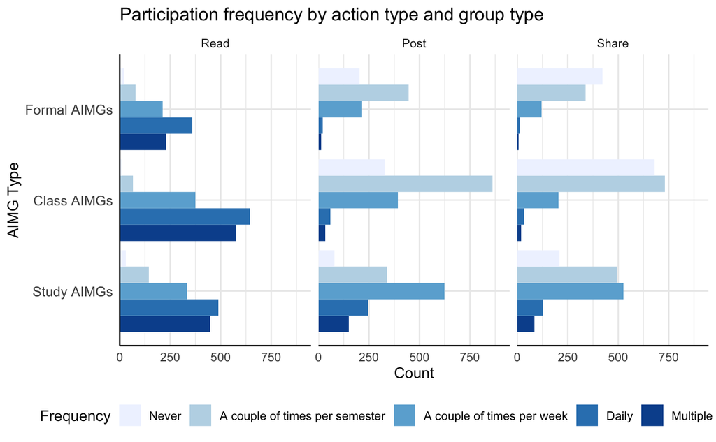

```r
use_frequency_figure <- raw_data %>% dplyr::select(study_read_frequency, formal_read_frequency, class_read_frequency,
                           study_post_frequency,formal_post_frequency, class_post_frequency,
                           study_share_frequency, formal_share_frequency, class_share_frequency) %>%
    pivot_longer(cols = c(study_read_frequency, formal_read_frequency, class_read_frequency,
                           study_post_frequency,formal_post_frequency, class_post_frequency,
                           study_share_frequency, formal_share_frequency, class_share_frequency),
                 names_to = "context", values_to = "frequency") %>%
  separate(context, into = c("group_type", "action_type", "other"), sep = "_") %>%
  dplyr::select(group_type, action_type, frequency) %>%
  mutate(frequency = factor(case_when(frequency == "never" ~ "Never",
                                      frequency == "a couple of times per semester" ~ "A couple of times per semester",
                                      frequency == "a couple of times per week" ~ "A couple of times per week",
                                      frequency == "daily" ~ "Daily",
                                      frequency == "multiple times per day" ~ "Multiple times per day"),
                            levels = c("Multiple times per day", "Daily","A couple of times per week","A couple of times per semester" ,"Never")),
         group_type = factor(case_when(group_type == "formal"~ "Formal AIMGs",
                                group_type == "class"~ "Class AIMGs",
                                group_type == "study" ~ "Study AIMGs"),
                             levels = c("Study AIMGs", "Class AIMGs", "Formal AIMGs")),
         action_type = factor(case_when(action_type == "read"~ "Read",
                                action_type == "post"~ "Post",
                                action_type == "share" ~ "Share"),
                             levels = c("Read", "Post", "Share"))) %>%
  group_by(group_type, action_type, frequency) %>%
  filter(!is.na(frequency)) %>%
  summarise(count = n()) %>%
  ggplot(aes(fill=factor(frequency), y=count, x=group_type)) +
    geom_bar(position="dodge", stat="identity") +
  scale_fill_brewer(palette = "Blues", direction = -1)+
  labs(fill = "Frequency", x = "AIMG Type", y = "Count", title="Participation frequency by action type and group type")+
  scale_y_continuous(expand = expansion(mult = c(0, .1)))+
  theme_minimal() + coord_flip()+
  theme(axis.line = element_line(colour = "black"),
        axis.text.y = element_text(size = 10),
        legend.position = "bottom") + guides(fill=guide_legend(reverse = TRUE)) +
  facet_wrap(~action_type)
use_frequency_figure

ggsave((filename="Figures/use_frequency_figure.pdf"), scale = 1, width = 10, height=5, dpi = 600, limitsize = TRUE, use_frequency_figure)
```

```r
raw_data %>% dplyr::select(study_read_frequency, formal_read_frequency, class_read_frequency,
                           study_post_frequency,formal_post_frequency, class_post_frequency,
                           study_share_frequency, formal_share_frequency, class_share_frequency) %>%
    pivot_longer(cols = c(study_read_frequency, formal_read_frequency, class_read_frequency,
                           study_post_frequency,formal_post_frequency, class_post_frequency,
                           study_share_frequency, formal_share_frequency, class_share_frequency), names_to = "context", values_to = "frequency") %>%
  separate(context, into = c("group_type", "action_type", "other"), sep = "_") %>%
  dplyr::select(group_type, action_type, frequency) %>%
  group_by(group_type, action_type, frequency) %>%
  filter(!is.na(frequency)) %>%
  summarise(count = n())  %>%
  mutate(perc = count/sum(count)*100) %>%
  arrange(group_type) #note, arrange ignores groups
```

| group_type | action_type | frequency | count | perc |
| --- | --- | --- | --- | --- |
| class | post | a couple of times per semester | 861 | 51.5260323 |
| class | post | a couple of times per week | 392 | 23.4590066 |
| class | post | daily | 58 | 3.4709755 |
| class | post | multiple times per day | 33 | 1.9748654 |
| class | post | never | 327 | 19.5691203 |
| class | read | a couple of times per semester | 65 | 3.8898863 |
| class | read | a couple of times per week | 375 | 22.4416517 |
| class | read | daily | 646 | 38.6594853 |
| class | read | multiple times per day | 576 | 34.4703770 |
| class | read | never | 9 | 0.5385996 |

[output cut: 35 more lines]

### Produce frequency scales

#### Class groups frequency (recode and combine)

Note: never = 0; a couple of times per semester = 0.25; a couple of times per week = 0.5; daily = 1; multiple times per day = 2; NA = 0 (because default to NA if not selected)

```r
raw_data<- raw_data %>%
  mutate(class_read_frequency = case_when(`_class_AIMG_read_Column2` == "never" ~ 0,
                                          `_class_AIMG_read_Column2` == "a couple of times per semester" ~ 0.25,
                                          `_class_AIMG_read_Column2` == "a couple of times per week" ~ 0.5,
                                          `_class_AIMG_read_Column2` == "daily" ~ 1,
                                          `_class_AIMG_read_Column2` == "multiple times per day" ~ 2,
                                          is.na(`_class_AIMG_read_Column2`) ~ 0)) %>%
  mutate(class_post_frequency = case_when(`_class_AIMG_post_Column2` == "never" ~ 0,
                                          `_class_AIMG_post_Column2` == "a couple of times per semester" ~ 0.25,
                                          `_class_AIMG_post_Column2` == "a couple of times per week" ~ 0.5,
                                          `_class_AIMG_post_Column2` == "daily" ~ 1,
                                          `_class_AIMG_post_Column2` == "multiple times per day" ~ 2,
                                          is.na(`_class_AIMG_post_Column2`) ~ 0)) %>%
  mutate(class_share_frequency = case_when(`_class_AIMG_share_Column2` == "never" ~ 0,
                                          `_class_AIMG_share_Column2` == "a couple of times per semester" ~ 0.25,
                                          `_class_AIMG_share_Column2` == "a couple of times per week" ~ 0.5,
                                          `_class_AIMG_share_Column2` == "daily" ~ 1,
                                          `_class_AIMG_share_Column2` == "multiple times per day" ~ 2,
                                          is.na(`_class_AIMG_share_Column2`) ~ 0))  %>%
  dplyr::select(-c(`_class_AIMG_read_Column2`, `_class_AIMG_post_Column2`, `_class_AIMG_share_Column2`))
```

Produce combined frequency variable

```r
raw_data<- raw_data %>%
  mutate(frequency_class = as.numeric(class_read_frequency+class_post_frequency+class_share_frequency))
```

#### Formal group frequency (recode and combine)

```r
raw_data<- raw_data %>%
  mutate(formal_read_frequency = case_when(`_formal_AIMG_read_Column2` == "never" ~ 0,
                                          `_formal_AIMG_read_Column2` == "a couple of times per semester" ~ 0.25,
                                          `_formal_AIMG_read_Column2` == "a couple of times per week" ~ 0.5,
                                          `_formal_AIMG_read_Column2` == "daily" ~ 1,
                                          `_formal_AIMG_read_Column2` == "multiple times per day" ~ 2,
                                          is.na(`_formal_AIMG_read_Column2`) ~ 0)) %>%
  mutate(formal_post_frequency = case_when(`_formal_AIMG_post_Column2` == "never" ~ 0,
                                          `_formal_AIMG_post_Column2` == "a couple of times per semester" ~ 0.25,
                                          `_formal_AIMG_post_Column2` == "a couple of times per week" ~ 0.5,
                                          `_formal_AIMG_post_Column2` == "daily" ~ 1,
                                          `_formal_AIMG_post_Column2` == "multiple times per day" ~ 2,
                                          is.na(`_formal_AIMG_post_Column2`) ~ 0)) %>%
  mutate(formal_share_frequency = case_when(`_formal_AIMG_share_Column2` == "never" ~ 0,
                                          `_formal_AIMG_share_Column2` == "a couple of times per semester" ~ 0.25,
                                          `_formal_AIMG_share_Column2` == "a couple of times per week" ~ 0.5,
                                          `_formal_AIMG_share_Column2` == "daily" ~ 1,
                                          `_formal_AIMG_share_Column2` == "multiple times per day" ~ 2,
                                          is.na(`_formal_AIMG_share_Column2`) ~ 0))  %>%
  dplyr::select(-c(`_formal_AIMG_read_Column2`, `_formal_AIMG_post_Column2`, `_formal_AIMG_share_Column2`))
```

Produce combined frequency variable

```r
raw_data<- raw_data %>%
  mutate(frequency_formal = as.numeric(formal_read_frequency+formal_post_frequency+formal_share_frequency))
```

#### Study-group frequency (recode and combine)

```r
raw_data<- raw_data %>%
  mutate(study_read_frequency = case_when(`_group_AIMG_read_Column2` == "never" ~ 0,
                                          `_group_AIMG_read_Column2` == "a couple of times per semester" ~ 0.25,
                                          `_group_AIMG_read_Column2` == "a couple of times per week" ~ 0.5,
                                          `_group_AIMG_read_Column2` == "daily" ~ 1,
                                          `_group_AIMG_read_Column2` == "multiple times per day" ~ 2,
                                          is.na(`_group_AIMG_read_Column2`) ~ 0)) %>%
  mutate(study_post_frequency = case_when(`_group_AIMG_post_Column2` == "never" ~ 0,
                                          `_group_AIMG_post_Column2` == "a couple of times per semester" ~ 0.25,
                                          `_group_AIMG_post_Column2` == "a couple of times per week" ~ 0.5,
                                          `_group_AIMG_post_Column2` == "daily" ~ 1,
                                          `_group_AIMG_post_Column2` == "multiple times per day" ~ 2,
                                          is.na(`_group_AIMG_post_Column2`) ~ 0)) %>%
  mutate(study_share_frequency = case_when(`_group_AIMG_share_Column2` == "never" ~ 0,
                                          `_group_AIMG_share_Column2` == "a couple of times per semester" ~ 0.25,
                                          `_group_AIMG_share_Column2` == "a couple of times per week" ~ 0.5,
                                          `_group_AIMG_share_Column2` == "daily" ~ 1,
                                          `_group_AIMG_share_Column2` == "multiple times per day" ~ 2,
                                          is.na(`_group_AIMG_share_Column2`) ~ 0))  %>%
  dplyr::select(-c(`_group_AIMG_read_Column2`, `_group_AIMG_post_Column2`, `_group_AIMG_share_Column2`))
```

Produce combined frequency variable

```r
raw_data<- raw_data %>%
  mutate(frequency_study = as.numeric(study_read_frequency+study_post_frequency+study_share_frequency))
```

### Combine to produce overall participation scales

```r
raw_data <- raw_data %>%
  mutate(class_overall_participation = as.numeric(frequency_class * use_proportion_class_AIMG),
         formal_overall_participation = as.numeric(frequency_formal * use_proportion_formal_AIMG),
         study_overall_participation = as.numeric(frequency_study * use_proportion_study_AIMG))
```

```r
raw_data %>%
  dplyr::select(class_overall_participation,
                    formal_overall_participation, study_overall_participation) %>%
  psych::describe()
```

|  | vars | n | mean | sd | median | trimmed | mad | min | max | range | skew | kurtosis | se |
| --- | --- | --- | --- | --- | --- | --- | --- | --- | --- | --- | --- | --- | --- |
| class_overall_participation | 1 | 1752 | 5.70 | 4.08 | 5.00 | 5.39 | 4.45 | 0 | 24 | 24 | 1.06 | 2.16 | 0.10 |
| formal_overall_participation | 2 | 1752 | 1.58 | 2.72 | 0.25 | 0.94 | 0.37 | 0 | 24 | 24 | 2.82 | 10.37 | 0.06 |
| study_overall_participation | 3 | 1752 | 4.22 | 5.04 | 2.50 | 3.24 | 3.34 | 0 | 24 | 24 | 1.92 | 3.83 | 0.12 |

# Visualise overall participation

```
Ignoring unknown parameters: guides
```

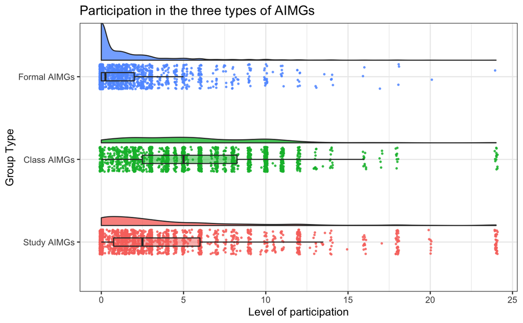

```r
raw_data %>%
  dplyr::select(class_overall_participation, formal_overall_participation, study_overall_participation) %>%
  pivot_longer(cols = c(class_overall_participation, formal_overall_participation, study_overall_participation), names_to = "group_type", values_to = "overall_participation") %>%
  mutate(group_type = factor(case_when(group_type == "study_overall_participation"~ "Study AIMGs",
                                group_type == "formal_overall_participation" ~ "Formal AIMGs",
                                group_type == "class_overall_participation" ~ "Class AIMGs"), levels = c("Study AIMGs", "Class AIMGs", "Formal AIMGs"))) %>%
  ggplot(aes(y = overall_participation, x = group_type, fill=group_type)) +
  geom_flat_violin(position = position_nudge(x = .2, y = 0), alpha = .8) +
  geom_point(aes(y = overall_participation, color = group_type), position = position_jitter(width = .15), size = .5, alpha = 0.8) +
  geom_boxplot(width = .1, guides = FALSE, outlier.shape = NA, alpha = 0.5) +
expand_limits(x = 3) +
  guides(fill = FALSE) +
  labs(x = "Group Type", y = "Level of participation", title = "Participation in the three types of AIMGs")+
  guides(color=FALSE)+
  coord_flip() +
theme_bw()
```

```r
#ggsave((filename="figures/usage_raincloud_plot.pdf"), scale = 1, width = 10, height=5, dpi = 600, limitsize = TRUE, raincloud_plot)
```

# Use purposes and motivations

## Create seperate datasets for the use purposes and motivations variables

```r
formal_uses_data <- raw_data %>% dplyr::select(starts_with("These groups are used")) %>% dplyr::select(contains("formal"))
class_uses_data <- raw_data %>% dplyr::select(starts_with("These groups are used")) %>% dplyr::select(contains("class"))
group_uses_data <- raw_data %>% dplyr::select(starts_with("These groups are used")) %>% dplyr::select(contains("to_group"))

formal_uses_data <- formal_uses_data %>%
  add_column(group_type = "formal")

class_uses_data <- class_uses_data %>%
  add_column(group_type = "class")

group_uses_data <- group_uses_data %>%
  add_column(group_type = "group")

formal_uses_data <- formal_uses_data %>%
  mutate(communicate_administrative = `These groups are used to_formal_communicate_administrative_Column2`,
         discuss_content = `These groups are used to_formal_discuss_content_Column2`,
         share_notes = `These groups are used to_formal_share_notes_Column2`,
         share_answers = `These groups are used to_formal_share_answers_Column2`,
         coordinate_groupwork = `These groups are used to_formal_coordinate_group_Column2`,
         encourage = `These groups are used to_formal_encourage_Column2`,
         share_non_academic = `These groups are used to_formal_share_non_academic_Column2`) %>%
  dplyr::select(-c(`These groups are used to_formal_communicate_administrative_Column2`, `These groups are used to_formal_discuss_content_Column2`,
            `These groups are used to_formal_share_notes_Column2`, `These groups are used to_formal_share_answers_Column2`,
            `These groups are used to_formal_coordinate_group_Column2`, `These groups are used to_formal_encourage_Column2`,
            `These groups are used to_formal_share_non_academic_Column2`))

class_uses_data <- class_uses_data %>%
  mutate(communicate_administrative = `These groups are used to_class_communicate_administrative_Column2`,
         discuss_content = `These groups are used to_class_discuss_academic_Column2`,
         share_notes = `These groups are used to_class_share_notes_Column2`,
         share_answers = `These groups are used to_class_share_answers_Column2`,
         coordinate_groupwork = `These groups are used to_class_coordinate_group_Column2`,
         encourage = `These groups are used to_class_encourage_Column2`,
         share_non_academic = `These groups are used to_class_share_non_academic_Column2`) %>%
  dplyr::select(-c(`These groups are used to_class_communicate_administrative_Column2`, `These groups are used to_class_discuss_academic_Column2`,
            `These groups are used to_class_share_notes_Column2`, `These groups are used to_class_share_answers_Column2`,
            `These groups are used to_class_coordinate_group_Column2`, `These groups are used to_class_encourage_Column2`,
            `These groups are used to_class_share_non_academic_Column2`))

group_uses_data <- group_uses_data %>%
  mutate(communicate_administrative = `These groups are used to_group_communicate_administrative_Column2`,
         discuss_content = `These groups are used to_group_discuss_academic_Column2`,
         share_notes = `These groups are used to_group_share_notes_Column2`,
         share_answers = `These groups are used to_group_share_answers_Column2`,
         coordinate_groupwork = `These groups are used to_group_coordinate_group_Column2`,
         encourage = `These groups are used to_group_encourage_Column2`,
         share_non_academic = `These groups are used to_group_share_non_academic_Column2`) %>%
  dplyr::select(-c(`These groups are used to_group_communicate_administrative_Column2`, `These groups are used to_group_discuss_academic_Column2`,
            `These groups are used to_group_share_notes_Column2`, `These groups are used to_group_share_answers_Column2`,
            `These groups are used to_group_coordinate_group_Column2`, `These groups are used to_group_encourage_Column2`,
            `These groups are used to_group_share_non_academic_Column2`))

raw_data_purposes <- rbind(formal_uses_data, class_uses_data, group_uses_data)
```

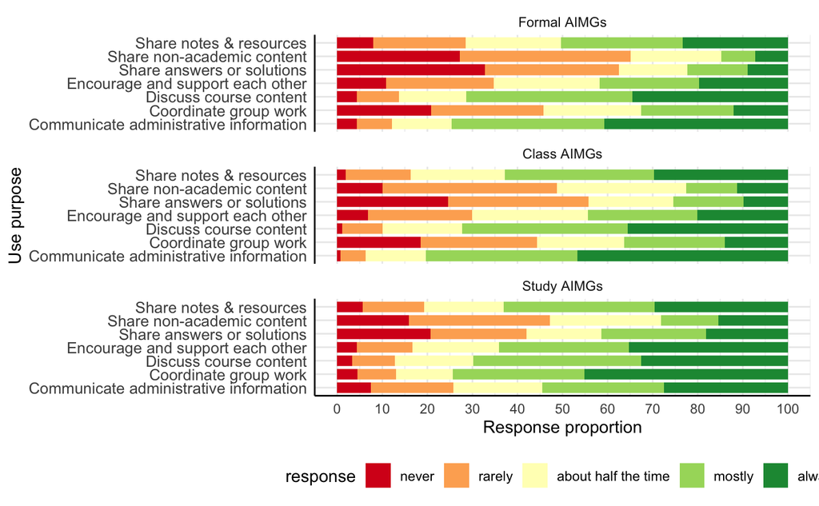

```r
levels = c("always", "mostly", "about half the time", "rarely", "never")

use_purposes_fig <- raw_data_purposes %>% filter(!is.na(communicate_administrative))  %>%
  mutate(`Communicate administrative information` = factor(communicate_administrative, levels, ordered=TRUE),
         `Discuss course content` = factor(discuss_content, levels, ordered=TRUE),
         `Share notes & resources` = factor(share_notes, levels, ordered=TRUE),
         `Share answers or solutions` = factor(share_answers, levels, ordered=TRUE),
         `Coordinate group work` = factor(coordinate_groupwork, levels, ordered=TRUE),
         `Encourage and support each other` = factor(encourage, levels, ordered=TRUE),
         `Share non-academic content` = factor(share_non_academic, levels, ordered=TRUE),
         group_type = case_when(group_type == "formal"~"Formal AIMGs",
                                group_type =="class"~"Class AIMGs",
                                group_type == "group" ~ "Study AIMGs")) %>%
  pivot_longer(cols = c(`Communicate administrative information`, `Discuss course content`,
                                            `Share notes & resources`, `Share answers or solutions`, `Coordinate group work` , `Encourage and support each other`, `Share non-academic content`), names_to = "Use_purpose", values_to = "response") %>%
 group_by(group_type, Use_purpose, response)  %>%
  summarise(n = n()) %>%
  ungroup() %>%
  group_by(group_type, Use_purpose) %>%
  mutate(count_resp = sum(n)) %>%
  group_by(Use_purpose, add = TRUE) %>%
  mutate(per = round(100*n/count_resp,2)) %>%
  mutate(group_type = factor(group_type, levels = c("Formal AIMGs", "Class AIMGs", "Study AIMGs"))) %>%
  ggplot(aes(x = Use_purpose, y = per, fill = response)) +
  geom_bar(stat = "identity", width = 0.8) + coord_flip() + facet_wrap(~group_type, ncol=1) +
  scale_fill_brewer(palette = "RdYlGn", direction = -1)+
  scale_y_continuous(breaks = seq(0, 100, by=10))+
  labs(x = "Use purpose", y = "Response proportion")+
  theme_minimal() +
  coord_flip()+
  theme(axis.line = element_line(colour = "black"),
        axis.text.y = element_text(size = 10),
        legend.position = "bottom") + guides(fill=guide_legend(nrow=1,byrow=TRUE, reverse = TRUE))
use_purposes_fig

ggsave((filename="Figures/use_purposes_figure.pdf"), scale = 1, width = 10, height=5, dpi = 600, limitsize = TRUE, use_purposes_fig)
```

```r
formal_outcomes_data <- raw_data %>% dplyr::select(starts_with("Please indicate your level of agreement with the following statements")) %>% dplyr::select(contains("formal"))
class_outcomes_data <- raw_data %>% dplyr::select(starts_with("Please indicate your level of agreement with the following statements")) %>% dplyr::select(contains("class"))
group_outcomes_data <- raw_data %>% dplyr::select(starts_with("Please indicate your level of agreement with the following statements")) %>% dplyr::select(contains("group_outcome"))

formal_outcomes_data <- formal_outcomes_data %>%
  add_column(group_type = "formal")

class_outcomes_data <- class_outcomes_data %>%
  add_column(group_type = "class")

group_outcomes_data <- group_outcomes_data %>%
  add_column(group_type = "group")

formal_outcomes_data <- formal_outcomes_data %>%
  mutate(accurate_administrative = `Please indicate your level of agreement with the following statements
 _formal_outcome_access_accurate_administrative_info_Column2`,
         use_academic_material = `Please indicate your level of agreement with the following statements
 _formal_outcome_access_useful_material_Column2`,
         understanding_of_work = `Please indicate your level of agreement with the following statements
 _formal_outcome_improves_understanding_Column2`,
         improves_AP = `Please indicate your level of agreement with the following statements
 _formal_outcome_improves_AP_Column2`,
         reduces_AS = `Please indicate your level of agreement with the following statements
 _formal_outcome_reduces_academic_stress_Column2`,
         cope_with_pressure = `Please indicate your level of agreement with the following statements
 _formal_outcome_cope_pressure_Column2`,
         group_work = `Please indicate your level of agreement with the following statements
 _formal_outcome_perform_group_work_Column2`,
 makes_anxious = `Please indicate your level of agreement with the following statements
 _formal_outcome_anxious_work_Column2`) %>%
  dplyr::select(-c(`Please indicate your level of agreement with the following statements
 _formal_outcome_access_accurate_administrative_info_Column2`, `Please indicate your level of agreement with the following statements
 _formal_outcome_access_useful_material_Column2`, `Please indicate your level of agreement with the following statements
 _formal_outcome_improves_understanding_Column2`,`Please indicate your level of agreement with the following statements
 _formal_outcome_improves_AP_Column2`, `Please indicate your level of agreement with the following statements
 _formal_outcome_reduces_academic_stress_Column2`, `Please indicate your level of agreement with the following statements
 _formal_outcome_cope_pressure_Column2`, `Please indicate your level of agreement with the following statements
 _formal_outcome_perform_group_work_Column2`, `Please indicate your level of agreement with the following statements
 _formal_outcome_anxious_work_Column2`))

class_outcomes_data <- class_outcomes_data %>%
  mutate(accurate_administrative = `Please indicate your level of agreement with the following statements_class_outcome_access_adminstrative_info_Column2`,
         use_academic_material = `Please indicate your level of agreement with the following statements_class_outcome_access_material_Column2`,
         understanding_of_work = `Please indicate your level of agreement with the following statements_class_outcome_improves_understanding_Column2`,
         improves_AP = `Please indicate your level of agreement with the following statements_class_outcome_improves_AP_Column2`,
         reduces_AS = `Please indicate your level of agreement with the following statements_class_outcome_reduces_stress_Column2`,
         cope_with_pressure = `Please indicate your level of agreement with the following statements_class_outcome_cope_pressure_Column2`,
         group_work = `Please indicate your level of agreement with the following statements_class_outcome_perform_group_Column2`,
 makes_anxious = `Please indicate your level of agreement with the following statements_class_outcome_anxious_work_Column2`) %>%
  dplyr::select(-c(`Please indicate your level of agreement with the following statements_class_outcome_access_adminstrative_info_Column2`,
                   `Please indicate your level of agreement with the following statements_class_outcome_access_material_Column2`,
                   `Please indicate your level of agreement with the following statements_class_outcome_improves_understanding_Column2`,
                   `Please indicate your level of agreement with the following statements_class_outcome_improves_AP_Column2`,
                   `Please indicate your level of agreement with the following statements_class_outcome_reduces_stress_Column2`,
                   `Please indicate your level of agreement with the following statements_class_outcome_cope_pressure_Column2`,
                   `Please indicate your level of agreement with the following statements_class_outcome_perform_group_Column2`,
                   `Please indicate your level of agreement with the following statements_class_outcome_anxious_work_Column2`))

group_outcomes_data <- group_outcomes_data %>%
  mutate(accurate_administrative = `Please indicate your level of agreement with the following statements_group_outcome_access_administrative_info_Column2`,
         use_academic_material = `Please indicate your level of agreement with the following statements_group_outcome_access_material_Column2`,
         understanding_of_work = `Please indicate your level of agreement with the following statements_group_outcome_improves_understanding_Column2`,
         improves_AP = `Please indicate your level of agreement with the following statements_group_outcome_improves_AP_Column2`,
         reduces_AS = `Please indicate your level of agreement with the following statements_group_outcome_reduces_stress_Column2`,
         cope_with_pressure = `Please indicate your level of agreement with the following statements_group_outcome_cope_pressure_Column2`,
         group_work = `Please indicate your level of agreement with the following statements_group_outcome_perform_group_Column2`,
 makes_anxious = `Please indicate your level of agreement with the following statements_group_outcome_anxious_work_Column2`) %>%
  dplyr::select(-c(`Please indicate your level of agreement with the following statements_group_outcome_access_administrative_info_Column2`,
                   `Please indicate your level of agreement with the following statements_group_outcome_access_material_Column2`,
                   `Please indicate your level of agreement with the following statements_group_outcome_improves_understanding_Column2`,
                   `Please indicate your level of agreement with the following statements_group_outcome_improves_AP_Column2`,
                   `Please indicate your level of agreement with the following statements_group_outcome_reduces_stress_Column2`,
                   `Please indicate your level of agreement with the following statements_group_outcome_cope_pressure_Column2`,
                   `Please indicate your level of agreement with the following statements_group_outcome_perform_group_Column2`,
                   `Please indicate your level of agreement with the following statements_group_outcome_anxious_work_Column2`))

raw_data_outcomes <- rbind(formal_outcomes_data, class_outcomes_data, group_outcomes_data)
```

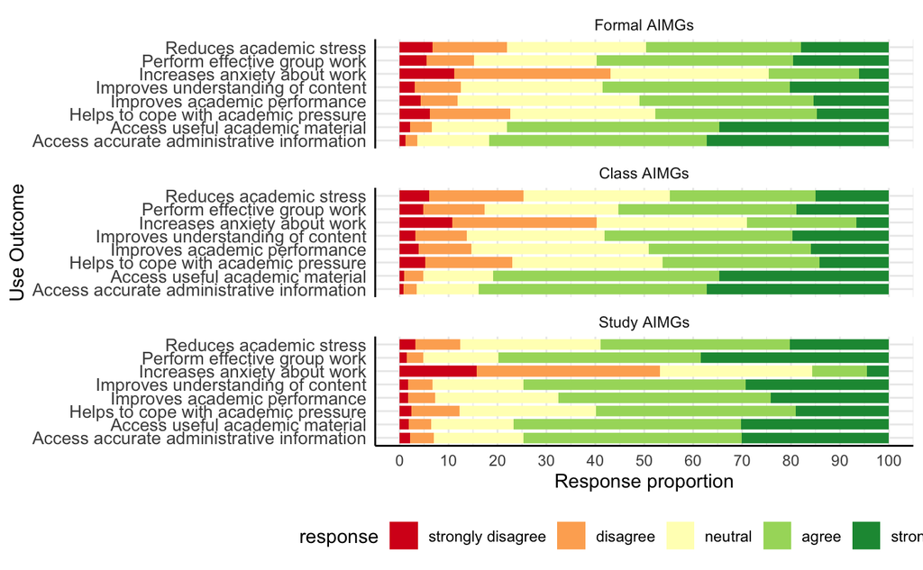

```r
levels = c("strongly agree", "agree", "neutral", "disagree", "strongly disagree")

use_outcomes_fig <- raw_data_outcomes %>% filter(!is.na(accurate_administrative))  %>%
  mutate(`Access accurate administrative information` = factor(accurate_administrative, levels, ordered=TRUE),
          `Access useful academic material` = factor(use_academic_material, levels, ordered=TRUE),
         `Improves understanding of content` = factor(understanding_of_work, levels, ordered=TRUE),
         `Improves academic performance` = factor(improves_AP, levels, ordered=TRUE),
         `Reduces academic stress` = factor(reduces_AS, levels, ordered=TRUE),
         `Helps to cope with academic pressure` = factor(cope_with_pressure, levels, ordered=TRUE),
         `Perform effective group work`  = factor(group_work, levels, ordered=TRUE),
         `Increases anxiety about work`  = factor(makes_anxious, levels, ordered=TRUE),
         group_type = case_when(group_type == "formal"~"Formal AIMGs",
                                group_type =="class"~"Class AIMGs",
                                group_type == "group" ~ "Study AIMGs")) %>%
           pivot_longer(cols = c(`Access accurate administrative information`,  `Access useful academic material`,
                                            `Improves understanding of content`, `Improves academic performance`, `Reduces academic stress`, `Helps to cope with academic pressure`, `Perform effective group work` , `Increases anxiety about work` ), names_to = "Use_outcome", values_to = "response") %>%
 group_by(group_type, Use_outcome, response)  %>%
  summarise(n = n()) %>%
  ungroup() %>%
  group_by(group_type, Use_outcome) %>%
  mutate(count_resp = sum(n)) %>%
  group_by(Use_outcome, add = TRUE) %>%
  mutate(per = round(100*n/count_resp,2)) %>%
  mutate(group_type = factor(group_type, levels = c("Formal AIMGs", "Class AIMGs", "Study AIMGs"))) %>%
  ggplot(aes(x = Use_outcome, y = per, fill = response)) +
  geom_bar(stat = "identity", width = 0.8) + coord_flip() + facet_wrap(~group_type, ncol=1) +
  scale_fill_brewer(palette = "RdYlGn", direction = -1)+
  scale_y_continuous(breaks = seq(0, 100, by=10))+
  labs(x = "Use Outcome", y = "Response proportion")+
  theme_minimal() +
  coord_flip()+
  theme(axis.line = element_line(colour = "black"),
        axis.text.y = element_text(size = 10),
        legend.position = "bottom") + guides(fill=guide_legend(nrow=1,byrow=TRUE, reverse = TRUE))
use_outcomes_fig
ggsave((filename="Figures/use_outcomes_figure.pdf"), scale = 1, width = 10, height=5, dpi = 600, limitsize = TRUE, use_outcomes_fig)
```

## correlation matrix

```r
raw_data %>%
  dplyr::select(class_overall_participation, formal_overall_participation, study_overall_participation,
         academic_performance, academic_stress_scale, GTS, LCS, OSI) %>%
  as.matrix() %>%
  rcorr(type = "spearman")
```

```
                             class_overall_participation formal_overall_participation
class_overall_participation                         1.00                         0.15
formal_overall_participation                        0.15                         1.00
study_overall_participation                         0.34                         0.08
academic_performance                                0.06                         0.02
academic_stress_scale                               0.01                         0.03
GTS                                                 0.00                         0.13
LCS                                                 0.14                         0.11
OSI                                                 0.05                        -0.02
                             study_overall_participation academic_performance academic_stress_scale
class_overall_participation                         0.34                 0.06                  0.01
formal_overall_participation                        0.08                 0.02                  0.03
study_overall_participation                         1.00                 0.06                  0.03
academic_performance                                0.06                 1.00                 -0.23
academic_stress_scale                               0.03                -0.23                  1.00
GTS                                                 0.01                 0.06                 -0.27
LCS                                                 0.14                 0.16                 -0.29
OSI                                                 0.04                 0.13                 -0.24
                               GTS   LCS   OSI
class_overall_participation   0.00  0.14  0.05
formal_overall_participation  0.13  0.11 -0.02
study_overall_participation   0.01  0.14  0.04
academic_performance          0.06  0.16  0.13
academic_stress_scale        -0.27 -0.29 -0.24
GTS                           1.00  0.57  0.43
LCS                           0.57  1.00  0.42
OSI                           0.43  0.42  1.00

n= 1752


P
                             class_overall_participation formal_overall_participation
class_overall_participation                              0.0000
formal_overall_participation 0.0000
study_overall_participation  0.0000                      0.0011
academic_performance         0.0136                      0.5046
academic_stress_scale        0.6973                      0.2783
GTS                          0.9648                      0.0000
LCS                          0.0000                      0.0000
OSI                          0.0576                      0.3338
                             study_overall_participation academic_performance academic_stress_scale
class_overall_participation  0.0000                      0.0136               0.6973
formal_overall_participation 0.0011                      0.5046               0.2783
study_overall_participation                              0.0144               0.1785
academic_performance         0.0144                                           0.0000
academic_stress_scale        0.1785                      0.0000
GTS                          0.6762                      0.0114               0.0000
LCS                          0.0000                      0.0000               0.0000
OSI                          0.0840                      0.0000               0.0000
                             GTS    LCS    OSI
class_overall_participation  0.9648 0.0000 0.0576
formal_overall_participation 0.0000 0.0000 0.3338
study_overall_participation  0.6762 0.0000 0.0840
academic_performance         0.0114 0.0000 0.0000
academic_stress_scale        0.0000 0.0000 0.0000
GTS                                 0.0000 0.0000
LCS                          0.0000        0.0000
OSI                          0.0000 0.0000
```

## Modeling

### Regression analysis with control variables

Multiple regression models will be produced to determine the predictive capacity of the AIMG participation variables over academic performance, academic stress and subjects’ perceptions of education quality and (operationalised through the good-teaching scale, learning community scale, and overall satisfaction index)indiinvolvement.

Controlling for gender, faculty, and study-year. [report controlled for but not in table]

predicting AP

```r
AP_model <- lm(academic_performance ~ class_overall_participation + formal_overall_participation + study_overall_participation + academic_stress_scale + LCS+GTS + age + faculty + study_year + gender, data = raw_data)
summary(AP_model)
```

```
Call:
lm(formula = academic_performance ~ class_overall_participation +
    formal_overall_participation + study_overall_participation +
    academic_stress_scale + LCS + GTS + age + faculty + study_year +
    gender, data = raw_data)

Residuals:
    Min      1Q  Median      3Q     Max
-4.9825 -1.1504 -0.0944  1.0539  4.7808

Coefficients:
                              Estimate Std. Error t value      Pr(>|t|)
(Intercept)                   8.914088   0.535803  16.637       < 2e-16 ***
class_overall_participation   0.010655   0.010905   0.977      0.328657
formal_overall_participation -0.065380   0.015782  -4.143 0.00003597725 ***
study_overall_participation   0.019544   0.008613   2.269      0.023374 *
academic_stress_scale        -0.037983   0.003109 -12.217       < 2e-16 ***
LCS                           0.364282   0.069436   5.246 0.00000017429 ***
GTS                          -0.242381   0.062154  -3.900 0.00009999918 ***
age                          -0.040224   0.016974  -2.370      0.017911 *
faculty1                     -0.465200   0.161627  -2.878      0.004048 **
faculty2                      0.452354   0.126169   3.585      0.000346 ***
faculty3                     -0.470673   0.120151  -3.917 0.00009301941 ***
faculty4                      0.746081   0.191741   3.891      0.000104 ***
faculty5                     -0.605468   0.126171  -4.799 0.00000173347 ***
faculty6                     -0.170060   0.174539  -0.974      0.330024
faculty7                      0.779572   0.130374   5.980 0.00000000271 ***
faculty8                     -1.153804   0.625784  -1.844      0.065387 .
faculty9                      0.236282   0.132287   1.786      0.074253 .
study_year1                   0.001696   0.090223   0.019      0.985007
study_year2                  -0.066590   0.099837  -0.667      0.504867
study_year3                  -0.177538   0.175703  -1.010      0.312423
study_year4                   0.182665   0.081172   2.250      0.024552 *
gender1                       0.277044   0.184173   1.504      0.132697
gender2                      -0.145865   0.188064  -0.776      0.438084
---
Signif. codes:  0 ‘***’ 0.001 ‘**’ 0.01 ‘*’ 0.05 ‘.’ 0.1 ‘ ’ 1

Residual standard error: 1.613 on 1729 degrees of freedom
Multiple R-squared:  0.2083,    Adjusted R-squared:  0.1982
F-statistic: 20.68 on 22 and 1729 DF,  p-value: < 0.00000000000000022
```

```r
AP_model_standardised_ceofs <- lm.beta(AP_model)
AP_model_standardised_ceofs
```

```
Call:
lm(formula = academic_performance ~ class_overall_participation +
    formal_overall_participation + study_overall_participation +
    academic_stress_scale + LCS + GTS + age + faculty + study_year +
    gender, data = raw_data)

Standardized Coefficients::
                 (Intercept)  class_overall_participation formal_overall_participation
                0.0000000000                 0.0241632240                -0.0987297967
 study_overall_participation        academic_stress_scale                          LCS
                0.0546449357                -0.2910600436                 0.1463747956
                         GTS                          age                     faculty1
               -0.1082490120                -0.0627226489                -0.0700359543
                    faculty2                     faculty3                     faculty4
                0.0965409030                -0.1080888205                 0.0945765484
                    faculty5                     faculty6                     faculty7
               -0.1367864580                -0.0240329332                 0.1647735228
                    faculty8                     faculty9                  study_year1
               -0.0763990297                 0.0467195287                 0.0006977985
                 study_year2                  study_year3                  study_year4
               -0.0230763106                -0.0503515905                 0.0759901948
                     gender1                      gender2
                0.0759927158                -0.0396662268
```

Predicting AS

```r
AS_model <- lm(academic_stress_scale ~ class_overall_participation + formal_overall_participation + study_overall_participation + academic_performance + LCS+GTS+ age + faculty + study_year + gender, data = raw_data)
summary(AS_model)
```

```
Call:
lm(formula = academic_stress_scale ~ class_overall_participation +
    formal_overall_participation + study_overall_participation +
    academic_performance + LCS + GTS + age + faculty + study_year +
    gender, data = raw_data)

Residuals:
    Min      1Q  Median      3Q     Max
-33.444  -8.043  -0.401   7.365  50.391

Coefficients:
                              Estimate Std. Error t value         Pr(>|t|)
(Intercept)                   90.89674    3.68296  24.680          < 2e-16 ***
class_overall_participation    0.05335    0.08094   0.659         0.509867
formal_overall_participation   0.10498    0.11768   0.892         0.372476
study_overall_participation    0.22933    0.06377   3.596         0.000332 ***
academic_performance          -2.09198    0.17124 -12.217          < 2e-16 ***
LCS                           -2.84644    0.51486  -5.529 0.00000003722079 ***
GTS                           -3.23977    0.45669  -7.094 0.00000000000189 ***
age                           -0.21600    0.12607  -1.713         0.086829 .
faculty1                      -0.30964    1.20234  -0.258         0.796797
faculty2                       5.40665    0.93078   5.809 0.00000000747682 ***
faculty3                       0.85509    0.89540   0.955         0.339720
faculty4                       1.81475    1.42853   1.270         0.204124
faculty5                      -0.77672    0.94239  -0.824         0.409937
faculty6                       4.16201    1.29180   3.222         0.001297 **
faculty7                       1.37911    0.97694   1.412         0.158231
faculty8                     -15.04649    4.63462  -3.247         0.001191 **
faculty9                       1.97099    0.98151   2.008         0.044786 *
study_year1                   -0.57610    0.66943  -0.861         0.389588
study_year2                   -1.94236    0.73955  -2.626         0.008705 **
study_year3                    0.33625    1.30431   0.258         0.796591
study_year4                    1.83571    0.60167   3.051         0.002315 **
gender1                        2.06512    1.36681   1.511         0.130994
gender2                       -4.14365    1.39237  -2.976         0.002961 **
---
Signif. codes:  0 ‘***’ 0.001 ‘**’ 0.01 ‘*’ 0.05 ‘.’ 0.1 ‘ ’ 1

Residual standard error: 11.97 on 1729 degrees of freedom
Multiple R-squared:  0.2574,    Adjusted R-squared:  0.248
F-statistic: 27.24 on 22 and 1729 DF,  p-value: < 0.00000000000000022
```

```r
#standardise coefficients
AS_model_standardised_ceofs <- lm.beta(AS_model)
AS_model_standardised_ceofs
```

```
Call:
lm(formula = academic_stress_scale ~ class_overall_participation +
    formal_overall_participation + study_overall_participation +
    academic_performance + LCS + GTS + age + faculty + study_year +
    gender, data = raw_data)

Standardized Coefficients::
                 (Intercept)  class_overall_participation formal_overall_participation
                 0.000000000                  0.015789873                  0.020687125
 study_overall_participation         academic_performance                          LCS
                 0.083675527                 -0.273001662                 -0.149258700
                         GTS                          age                     faculty1
                -0.188819964                 -0.043953925                 -0.006083491
                    faculty2                     faculty3                     faculty4
                 0.150580970                  0.025626062                  0.030020872
                    faculty5                     faculty6                     faculty7
                -0.022899437                  0.076756618                  0.038039749
                    faculty8                     faculty9                  study_year1
                -0.130016755                  0.050858213                 -0.030936384
                 study_year2                  study_year3                  study_year4
                -0.087839977                  0.012445072                  0.099658661
                     gender1                      gender2
                 0.073922544                 -0.147049111
```

```r
confint(AS_model_standardised_ceofs)
```

```
                                   2.5 %     97.5 %
(Intercept)                  -7.22352748 7.22352748
class_overall_participation  -0.14296047 0.17454021
formal_overall_participation -0.21011583 0.25149008
study_overall_participation  -0.04140689 0.20875794
academic_performance         -0.60886229 0.06285897
LCS                          -1.15907770 0.86056030
GTS                          -1.08454445 0.70690452
age                          -0.29121667 0.20330882
faculty1                     -2.36427606 2.35210908
faculty2                     -1.67499482 1.97615676
faculty3                     -1.73055214 1.78180426
faculty4                     -2.77179866 2.83184040
faculty5                     -1.87123766 1.82543879
faculty6                     -2.45689611 2.61040935
faculty7                     -1.87807289 1.95415239
faculty8                     -9.22006433 8.96003082
faculty9                     -1.87421446 1.97593089
study_year1                  -1.34392231 1.28204954
study_year2                  -1.53834271 1.36266275
study_year3                  -2.54574740 2.57063754
study_year4                  -1.08041519 1.27973252
gender1                      -2.60684578 2.75469086
gender2                      -2.87795652 2.58385829
```

```r
confint(AS_model)
```

```
                                    2.5 %      97.5 %
(Intercept)                   83.67320843 98.12026340
class_overall_participation   -0.10539622  0.21210446
formal_overall_participation  -0.12582673  0.33577918
study_overall_participation    0.10424726  0.35441210
academic_performance          -2.42783787 -1.75611661
LCS                           -3.85626339 -1.83662539
GTS                           -4.13548959 -2.34404062
age                           -0.46326087  0.03126461
faculty1                      -2.66783689  2.04854825
faculty2                       3.58107770  7.23222927
faculty3                      -0.90108803  2.61126836
faculty4                      -0.98706572  4.61657334
faculty5                      -2.62505839  1.07161806
faculty6                       1.62836085  6.69566631
faculty7                      -0.53700483  3.29522045
faculty8                     -24.13654169 -5.95644654
faculty9                       0.04591864  3.89606400
study_year1                   -1.88908885  0.73688299
study_year2                   -3.39285922 -0.49185376
study_year3                   -2.22193892  2.89444602
study_year4                    0.65563983  3.01578754
gender1                       -0.61564436  4.74589228
gender2                       -6.87456000 -1.41274519
```

Predicting LCS

```r
LCS_model <- lm(LCS ~ class_overall_participation + formal_overall_participation + study_overall_participation + academic_performance + academic_stress_scale+GTS+ age + faculty + study_year + gender, data = raw_data)
summary(LCS_model)
```

```
Call:
lm(formula = LCS ~ class_overall_participation + formal_overall_participation +
    study_overall_participation + academic_performance + academic_stress_scale +
    GTS + age + faculty + study_year + gender, data = raw_data)

Residuals:
    Min      1Q  Median      3Q     Max
-2.1594 -0.3350  0.0351  0.3633  2.0111

Coefficients:
                              Estimate Std. Error t value     Pr(>|t|)
(Intercept)                   1.836388   0.193327   9.499      < 2e-16 ***
class_overall_participation   0.018223   0.003722   4.895 0.0000010729 ***
formal_overall_participation  0.003427   0.005449   0.629      0.52945
study_overall_participation   0.011123   0.002952   3.768      0.00017 ***
academic_performance          0.043015   0.008199   5.246 0.0000001743 ***
academic_stress_scale        -0.006103   0.001104  -5.529 0.0000000372 ***
GTS                           0.497466   0.017806  27.939      < 2e-16 ***
age                          -0.010371   0.005837  -1.777      0.07579 .
faculty1                      0.074330   0.055644   1.336      0.18178
faculty2                      0.013554   0.043515   0.311      0.75547
faculty3                     -0.030630   0.041464  -0.739      0.46017
faculty4                      0.056180   0.066162   0.849      0.39593
faculty5                      0.032445   0.043637   0.744      0.45726
faculty6                      0.065568   0.059972   1.093      0.27441
faculty7                      0.046390   0.045247   1.025      0.30539
faculty8                     -0.163551   0.215212  -0.760      0.44739
faculty9                     -0.039712   0.045489  -0.873      0.38278
study_year1                   0.012905   0.031002   0.416      0.67725
study_year2                   0.004792   0.034311   0.140      0.88893
study_year3                  -0.089184   0.060356  -1.478      0.13969
study_year4                   0.065180   0.027890   2.337      0.01955 *
gender1                       0.030086   0.063324   0.475      0.63477
gender2                       0.125846   0.064564   1.949      0.05144 .
---
Signif. codes:  0 ‘***’ 0.001 ‘**’ 0.01 ‘*’ 0.05 ‘.’ 0.1 ‘ ’ 1

Residual standard error: 0.5542 on 1729 degrees of freedom
Multiple R-squared:  0.421, Adjusted R-squared:  0.4136
F-statistic: 57.14 on 22 and 1729 DF,  p-value: < 0.00000000000000022
```

```r
#standardise coefficients
LCS_model_standardised_ceofs <- lm.beta(LCS_model)
LCS_model_standardised_ceofs
```

```
Call:
lm(formula = LCS ~ class_overall_participation + formal_overall_participation +
    study_overall_participation + academic_performance + academic_stress_scale +
    GTS + age + faculty + study_year + gender, data = raw_data)

Standardized Coefficients::
                 (Intercept)  class_overall_participation formal_overall_participation
                 0.000000000                  0.102846381                  0.012880973
 study_overall_participation         academic_performance        academic_stress_scale
                 0.077396863                  0.107050124                 -0.116379859
                         GTS                          age                     faculty1
                 0.552918492                 -0.040245695                  0.027849627
                    faculty2                     faculty3                     faculty4
                 0.007199029                 -0.017505972                  0.017723436
                    faculty5                     faculty6                     faculty7
                 0.018242128                  0.023060535                  0.024401953
                    faculty8                     faculty9                  study_year1
                -0.026951336                 -0.019541893                  0.013216189
                 study_year2                  study_year3                  study_year4
                 0.004133124                 -0.062947946                  0.067482162
                     gender1                      gender2
                 0.020537755                  0.085168761
```

```r
confint(LCS_model)
```

```
                                     2.5 %       97.5 %
(Intercept)                   1.4572086056  2.215568013
class_overall_participation   0.0109217418  0.025523873
formal_overall_participation -0.0072605376  0.014115521
study_overall_participation   0.0053334617  0.016912548
academic_performance          0.0269335455  0.059095635
academic_stress_scale        -0.0082675868 -0.003937610
GTS                           0.4625436194  0.532389011
age                          -0.0218189092  0.001077479
faculty1                     -0.0348059873  0.183466821
faculty2                     -0.0717933842  0.098901501
faculty3                     -0.1119547898  0.050693910
faculty4                     -0.0735855209  0.185944884
faculty5                     -0.0531407915  0.118031457
faculty6                     -0.0520575597  0.183194183
faculty7                     -0.0423555152  0.135135031
faculty8                     -0.5856549451  0.258552908
faculty9                     -0.1289327253  0.049507733
study_year1                  -0.0478992588  0.073710194
study_year2                  -0.0625032218  0.072088002
study_year3                  -0.2075629092  0.029194486
study_year4                   0.0104790898  0.119881354
gender1                      -0.0941149087  0.154286174
gender2                      -0.0007870395  0.252478344
```

Predicting GTS

```r
GTS_model <- lm(GTS ~ class_overall_participation + formal_overall_participation + study_overall_participation + academic_performance + academic_stress_scale+LCS+ age + faculty + study_year + gender, data = raw_data)
summary(GTS_model)
```

```
Call:
lm(formula = GTS ~ class_overall_participation + formal_overall_participation +
    study_overall_participation + academic_performance + academic_stress_scale +
    LCS + age + faculty + study_year + gender, data = raw_data)

Residuals:
     Min       1Q   Median       3Q      Max
-2.10216 -0.40900  0.01846  0.38992  2.52456

Coefficients:
                              Estimate Std. Error t value         Pr(>|t|)
(Intercept)                   1.396135   0.219772   6.353 0.00000000026994 ***
class_overall_participation  -0.016475   0.004183  -3.938 0.00008531825021 ***
formal_overall_participation  0.020045   0.006091   3.291          0.00102 **
study_overall_participation   0.001790   0.003323   0.539          0.59008
academic_performance         -0.035972   0.009224  -3.900 0.00009999917945 ***
academic_stress_scale        -0.008730   0.001231  -7.094 0.00000000000189 ***
LCS                           0.625247   0.022379  27.939          < 2e-16 ***
age                           0.019286   0.006533   2.952          0.00320 **
faculty1                     -0.018863   0.062413  -0.302          0.76252
faculty2                      0.201659   0.048544   4.154 0.00003424613090 ***
faculty3                     -0.052334   0.046475  -1.126          0.26030
faculty4                     -0.052289   0.074179  -0.705          0.48097
faculty5                     -0.012205   0.048928  -0.249          0.80304
faculty6                     -0.002758   0.067258  -0.041          0.96729
faculty7                     -0.181862   0.050553  -3.597          0.00033 ***
faculty8                      0.041123   0.241313   0.170          0.86471
faculty9                     -0.031341   0.051004  -0.614          0.53897
study_year1                   0.040720   0.034744   1.172          0.24136
study_year2                  -0.041015   0.038454  -1.067          0.28630
study_year3                  -0.038059   0.067702  -0.562          0.57408
study_year4                   0.009877   0.031316   0.315          0.75250
gender1                       0.019519   0.070996   0.275          0.78341
gender2                      -0.135996   0.072389  -1.879          0.06045 .
---
Signif. codes:  0 ‘***’ 0.001 ‘**’ 0.01 ‘*’ 0.05 ‘.’ 0.1 ‘ ’ 1

Residual standard error: 0.6213 on 1729 degrees of freedom
Multiple R-squared:  0.4109,    Adjusted R-squared:  0.4034
F-statistic: 54.82 on 22 and 1729 DF,  p-value: < 0.00000000000000022
```

```r
#standardise coefficients
GTS_model_standardised_ceofs <- lm.beta(GTS_model)
GTS_model_standardised_ceofs
```

```
Call:
lm(formula = GTS ~ class_overall_participation + formal_overall_participation +
    study_overall_participation + academic_performance + academic_stress_scale +
    LCS + age + faculty + study_year + gender, data = raw_data)

Standardized Coefficients::
                 (Intercept)  class_overall_participation formal_overall_participation
                0.0000000000                -0.0836591765                 0.0677767964
 study_overall_participation         academic_performance        academic_stress_scale
                0.0112079915                -0.0805449214                -0.1497888305
                         LCS                          age                     faculty1
                0.5625413672                 0.0673359592                -0.0063585826
                    faculty2                     faculty3                     faculty4
                0.0963663116                -0.0269101456                -0.0148415299
                    faculty5                     faculty6                     faculty7
               -0.0061741880                -0.0008728265                -0.0860691341
                    faculty8                     faculty9                  study_year1
                0.0060969561                -0.0138759181                 0.0375182302
                 study_year2                  study_year3                  study_year4
               -0.0318253404                -0.0241687152                 0.0091999996
                     gender1                      gender2
                0.0119880009                -0.0828078685
```

```r
confint(GTS_model)
```

```
                                    2.5 %       97.5 %
(Intercept)                   0.965087816  1.827182925
class_overall_participation  -0.024680479 -0.008270421
formal_overall_participation  0.008098651  0.031991364
study_overall_participation  -0.004726411  0.008306995
academic_performance         -0.054063957 -0.017879981
academic_stress_scale        -0.011143644 -0.006316339
LCS                           0.581354335  0.669140481
age                           0.006471602  0.032099652
faculty1                     -0.141275389  0.103549895
faculty2                      0.106447529  0.296870899
faculty3                     -0.143487231  0.038820062
faculty4                     -0.197777769  0.093200459
faculty5                     -0.108169618  0.083758706
faculty6                     -0.134674156  0.129157448
faculty7                     -0.281014306 -0.082710056
faculty8                     -0.432172627  0.514418374
faculty9                     -0.131377359  0.068694366
study_year1                  -0.027424541  0.108864446
study_year2                  -0.116435823  0.034405548
study_year3                  -0.170844923  0.094726916
study_year4                  -0.051543720  0.071297130
gender1                      -0.119728518  0.158765872
gender2                      -0.277975129  0.005982633
```

Predicting OSI: ordinal logistic regression

Below we use the polr command from the MASS package to estimate an ordered logistic regression model. (proportional odds logistic regression)

See below for interpretation of coefficients

```r
OSI_model <- polr(OSI ~ class_overall_participation + formal_overall_participation + study_overall_participation + academic_performance + academic_stress_scale+LCS +GTS + age + faculty + study_year + gender, data = raw_data, Hess=TRUE)
summary(OSI_model)
```

```
Call:
polr(formula = OSI ~ class_overall_participation + formal_overall_participation +
    study_overall_participation + academic_performance + academic_stress_scale +
    LCS + GTS + age + faculty + study_year + gender, data = raw_data,
    Hess = TRUE)

Coefficients:
                                Value Std. Error  t value
class_overall_participation   0.01000   0.013495  0.74124
formal_overall_participation -0.04297   0.019320 -2.22401
study_overall_participation   0.01312   0.010779  1.21744
academic_performance          0.09414   0.030127  3.12480
academic_stress_scale        -0.01144   0.004027 -2.84073
LCS                           0.79890   0.089903  8.88626
GTS                           0.86248   0.080103 10.76708
age                           0.04396   0.023919  1.83802
faculty1                      0.32662   0.198158  1.64826
faculty2                     -0.06464   0.153262 -0.42178
faculty3                      0.29591   0.146466  2.02034
faculty4                     -0.43539   0.235484 -1.84890
faculty5                      0.32065   0.157067  2.04148
faculty6                      0.36762   0.215026  1.70965
faculty7                      0.08438   0.159031  0.53058
faculty8                     -1.45911   0.743559 -1.96233
faculty9                      0.44775   0.161610  2.77055
study_year1                   0.13457   0.113373  1.18693
study_year2                  -0.10565   0.124791 -0.84664
study_year3                   0.01752   0.218537  0.08018
study_year4                  -0.07600   0.101156 -0.75132
gender1                       0.58824   0.211579  2.78022
gender2                       0.60305   0.216571  2.78455

Intercepts:
    Value   Std. Error t value
1|2  2.5592  0.7772     3.2928
2|3  4.2000  0.7680     5.4691
3|4  5.8739  0.7717     7.6119
4|5  9.0862  0.7914    11.4817

Residual Deviance: 3658.17
AIC: 3712.17
```

To get p-values for coefficients

```r
ctable <- coef(summary(OSI_model))
p <- pnorm(abs(ctable[, "t value"]), lower.tail = FALSE) * 2
exp_coef <- exp(ctable[, "Value"])
(ctable <- cbind(ctable, "p value" = p, "exp_coef" = exp_coef))
```

```
                                   Value  Std. Error     t value      p value     exp_coef
class_overall_participation   0.01000279 0.013494634  0.74124204 4.585467e-01    1.0100530
formal_overall_participation -0.04296840 0.019320221 -2.22401207 2.614763e-02    0.9579417
study_overall_participation   0.01312308 0.010779211  1.21744374 2.234354e-01    1.0132096
academic_performance          0.09414096 0.030127051  3.12479831 1.779270e-03    1.0987146
academic_stress_scale        -0.01143921 0.004026855 -2.84072990 4.501042e-03    0.9886260
LCS                           0.79890384 0.089903227  8.88626429 6.319792e-19    2.2231027
GTS                           0.86247832 0.080103293 10.76707706 4.923854e-27    2.3690246
age                           0.04396349 0.023918991  1.83801605 6.606004e-02    1.0449442
faculty1                      0.32661595 0.198158289  1.64825783 9.929977e-02    1.3862690
faculty2                     -0.06464284 0.153261675 -0.42178088 6.731850e-01    0.9374022
faculty3                      0.29591108 0.146466227  2.02033659 4.334849e-02    1.3443506
faculty4                     -0.43538616 0.235484148 -1.84889795 6.447255e-02    0.6470148
faculty5                      0.32064924 0.157067249  2.04147741 4.120340e-02    1.3780221
faculty6                      0.36761978 0.215026118  1.70965177 8.733029e-02    1.4442928
faculty7                      0.08437827 0.159030857  0.53057795 5.957113e-01    1.0880404
faculty8                     -1.45910627 0.743559405 -1.96232643 4.972449e-02    0.2324439
faculty9                      0.44774815 0.161610006  2.77054718 5.596219e-03    1.5647845
study_year1                   0.13456568 0.113372755  1.18693139 2.352547e-01    1.1440398
study_year2                  -0.10565354 0.124791046 -0.84664361 3.971938e-01    0.8997363
study_year3                   0.01752268 0.218537487  0.08018156 9.360929e-01    1.0176771
study_year4                  -0.07600028 0.101155898 -0.75131830 4.524611e-01    0.9268159
gender1                       0.58823655 0.211579236  2.78021872 5.432230e-03    1.8008100
gender2                       0.60305283 0.216571082  2.78454918 5.360219e-03    1.8276899
1|2                           2.55921922 0.777224316  3.29276782 9.920636e-04   12.9257212
2|3                           4.20004125 0.767959295  5.46909357 4.523429e-08   66.6890816
3|4                           5.87391172 0.771677561  7.61187316 2.701516e-14  355.6374153
4|5                           9.08622280 0.791364587 11.48171520 1.630142e-30 8832.7599068
```

```r
#confint.default(OSI_model) #check...
```

These coefficients are called proportional odds ratios and we would interpret these pretty much as we would odds ratios from a binary logistic regression. (see last column above)

# Further post hoc exploratory analyses

### SEM option

With formal groups

```r
model <- 'academic_performance ~ class_overall_participation + formal_overall_participation + study_overall_participation + academic_stress_scale + GTS + LCS
academic_stress_scale ~ class_overall_participation + formal_overall_participation + study_overall_participation + academic_performance + GTS + LCS
GTS ~ class_overall_participation + formal_overall_participation + study_overall_participation + academic_performance + academic_stress_scale + LCS
LCS ~ class_overall_participation + formal_overall_participation + study_overall_participation  + academic_performance + academic_stress_scale + GTS
class_overall_participation~~formal_overall_participation
class_overall_participation~~study_overall_participation
formal_overall_participation~~study_overall_participation'
```

```r
model <- 'academic_performance ~ class_overall_participation + formal_overall_participation + study_overall_participation + academic_stress_scale + GTS + LCS
academic_stress_scale ~ class_overall_participation + formal_overall_participation + study_overall_participation + academic_performance + GTS + LCS
GTS ~ class_overall_participation + formal_overall_participation + study_overall_participation + academic_performance + academic_stress_scale + LCS
LCS ~ class_overall_participation + formal_overall_participation + study_overall_participation  + academic_performance + academic_stress_scale + GTS'
```

```r
raw_data_for_sem <- raw_data %>% dplyr::select(class_overall_participation, formal_overall_participation, study_overall_participation, GTS, LCS, academic_performance)
```

```r
raw_data_for_sem <- raw_data_for_sem
```

```r
fit <- sem(model, data=raw_data)
```

```
lavaan WARNING:
    Could not compute standard errors! The information matrix could
    not be inverted. This may be a symptom that the model is not
    identified.
```

```r
summary(fit, fit.measures = T, standardize = T)
```

```
lavaan 0.6-7 ended normally after 61 iterations

  Estimator                                         ML
  Optimization method                           NLMINB
  Number of free parameters                         28

  Number of observations                          1752

Model Test User Model:

  Test statistic                                    NA
  Degrees of freedom                                -6
  P-value (Unknown)                                 NA

User Model versus Baseline Model:

  Comparative Fit Index (CFI)                       NA
  Tucker-Lewis Index (TLI)                          NA

Loglikelihood and Information Criteria:

  Loglikelihood user model (H0)             -14011.132
  Loglikelihood unrestricted model (H1)     -14011.132

  Akaike (AIC)                               28078.265
  Bayesian (BIC)                             28231.383
  Sample-size adjusted Bayesian (BIC)        28142.430

Root Mean Square Error of Approximation:

  RMSEA                                             NA
  90 Percent confidence interval - lower            NA
  90 Percent confidence interval - upper            NA
  P-value RMSEA <= 0.05                             NA

Standardized Root Mean Square Residual:

  SRMR                                           0.000

Parameter Estimates:
```

[output cut: 27 more lines]

```
    LCS                      0.279       NA                      0.279    0.251
  LCS ~
    clss_vrll_prtc           0.017       NA                      0.017    0.093
    frml_vrll_prtc           0.009       NA                      0.009    0.034
    stdy_vrll_prtc           0.012       NA                      0.012    0.086
    acadmc_prfrmnc           0.032       NA                      0.032    0.079
    acdmc_strss_sc          -0.010       NA                     -0.010   -0.186
    GTS                      0.324       NA                      0.324    0.360

Variances:
                   Estimate  Std.Err  z-value  P(>|z|)   Std.lv  Std.all
   .acadmc_prfrmnc    3.002       NA                      3.002    0.926
   .acdmc_strss_sc  188.516       NA                    188.516    0.990
   .GTS               0.459       NA                      0.459    0.710
   .LCS               0.326       NA                      0.326    0.623
```

```r
semPaths(fit, rotation=2)
```

[output not shown]